# **Análise do Mercado de GLP (Gás Liquifeito de Petróleo ou "gás de cozinha") no Brasil (2023–2025)**

# 📌 Como visualizar os mapas interativos

Este projeto contém mapas interativos gerados com Plotly. Para visualizá-los corretamente:

🔸 **Baixe o notebook em formato HTML**  
🔸 Abra o arquivo `.html` no seu navegador (Chrome, Firefox, etc.)

### Os dados utilizados neste estudo foram obtidos através da [Agência Nacional do Petróleo (ANP)](https://dados.gov.br/dados/conjuntos-dados/serie-historica-de-precos-de-combustiveis-e-de-glp) e abrangem o período de janeiro 2023 ao primeiro semestre 2025.

```python
# Processamento e análise de dados
import pandas as pd
import numpy as np

# Vizualização e criação de dados
import matplotlib.pyplot as plt
import seaborn as sns

# Criação de mapas
import json
import geopandas as gpd
import plotly.express as px
from plotly.subplots import make_subplots
import plotly.graph_objects as go

# ignorar avisos
import warnings
warnings.filterwarnings('ignore')
```

# 1. **Limpeza de dados**

```python
# Carregar dados como um pandas dataframe
df = pd.read_csv(r"C:\Users\renil\Desktop\Data\glp-23_25.csv", sep=None, engine='python')
```

```python
# Excluinr colunas que não serão úteis
df = df.drop(['CNPJ da Revenda' , 'Nome da Rua' , 'Numero Rua' , 'Complemento' , 'Bairro' , 'Cep' , 'Produto' , 'Valor de Compra'] , axis= 1)
```

```python
# Procurar por valores nulos
df.isna().sum()
```

```
Regiao - Sigla       0
Estado - Sigla       0
Municipio            0
Revenda              0
Data da Coleta       0
Valor de Venda       0
Unidade de Medida    0
Bandeira             0
dtype: int64
```

# 2. **Panorama estatístico e geral**

```python
# Resumo do dataframe
df.info()
```

```
<class 'pandas.core.frame.DataFrame'>
RangeIndex: 459342 entries, 0 to 459341
Data columns (total 8 columns):
 #   Column             Non-Null Count   Dtype
---  ------             --------------   -----
 0   Regiao - Sigla     459342 non-null  object
 1   Estado - Sigla     459342 non-null  object
 2   Municipio          459342 non-null  object
 3   Revenda            459342 non-null  object
 4   Data da Coleta     459342 non-null  object
 5   Valor de Venda     459342 non-null  object
 6   Unidade de Medida  459342 non-null  object
 7   Bandeira           459342 non-null  object
dtypes: object(8)
memory usage: 28.0+ MB
```

```python
# Visualizar as 5 primeiras linhas
df.head(5)
```

|  | Regiao - Sigla | Estado - Sigla | Municipio | Revenda | Data da Coleta | Valor de Venda | Unidade de Medida | Bandeira |
| --- | --- | --- | --- | --- | --- | --- | --- | --- |
| 0 | CO | MS | CAMPO GRANDE | COMPANHIA ULTRAGAZ S A | 05/01/2023 | 120 | R$ / 13 kg | ULTRAGAZ |
| 1 | CO | MS | CAMPO GRANDE | SUPERGASBRAS ENERGIA LTDA | 05/01/2023 | 120 | R$ / 13 kg | SUPERGASBRAS ENERGIA |
| 2 | S | RS | PELOTAS | SUPERGASBRAS ENERGIA LTDA | 03/01/2023 | 108 | R$ / 13 kg | SUPERGASBRAS ENERGIA |
| 3 | SE | MG | MONTES CLAROS | SUPERGASBRAS ENERGIA LTDA | 05/01/2023 | 120 | R$ / 13 kg | SUPERGASBRAS ENERGIA |
| 4 | NE | CE | JUAZEIRO DO NORTE | COMERCIO DE PETROLEO COLORADO LTDA | 05/01/2023 | 109 | R$ / 13 kg | NACIONAL GÁS BUTANO |

```python
# Resumo estatístico
df.describe()
```

|  | Regiao - Sigla | Estado - Sigla | Municipio | Revenda | Data da Coleta | Valor de Venda | Unidade de Medida | Bandeira |
| --- | --- | --- | --- | --- | --- | --- | --- | --- |
| count | 459342 | 459342 | 459342 | 459342 | 459342 | 459342 | 459342 | 459342 |
| unique | 5 | 27 | 467 | 7553 | 651 | 625 | 1 | 14 |
| top | SE | SP | MANAUS | CASCOL COMBUSTIVEIS PARA VEICULOS LTDA | 31/07/2023 | 100 | R$ / 13 kg | BRANCA |
| freq | 195102 | 104224 | 10114 | 1533 | 2134 | 44627 | 459342 | 109774 |

# **2.1 Disperção de preços**

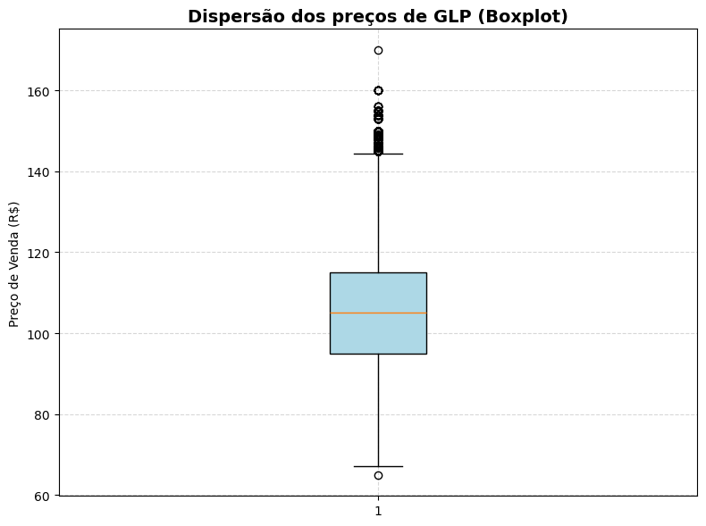

```python
# corrigir possíveis erros de formatação
df['Valor de Venda'] = df['Valor de Venda'].astype(str).str.replace(",", ".").str.replace('"', '').astype(float)

# Criar boxplot
plt.figure(figsize=(8, 6))
plt.boxplot(df['Valor de Venda'], vert=True, patch_artist=True, boxprops=dict(facecolor='lightblue'))

# Estilizar e exibir gráfioco
plt.title('Dispersão dos preços de GLP (Boxplot)', fontsize=14, fontweight='bold')
plt.ylabel('Preço de Venda (R$)')
plt.grid(True, linestyle='--', alpha=0.5)
plt.tight_layout()
plt.show()
```

### É possível observar uma grande dispersão dos dados em relação a média, e a presença de muitos outliers (o que pode indicar preços abusivos)

# 3. **Tendências regionais de preço**

## 3.1 Preço médio do GLP por estado

```python
# corrigir possíveis erros de formatação
df['Valor de Venda'] = df['Valor de Venda'].astype(str).str.replace(",", ".").str.replace('"', '').astype(float)

# Agrupar por estado e calcular preço médio
preco_estado = df.groupby('Estado - Sigla')['Valor de Venda'].median().reset_index(name='Preço Médio').round(2)

# Carregar JSON com os dados dos estados
with open(r"C:\Users\renil\Downloads\brazil-states.geojson") as f:
    geojson = json.load(f)

# Criar e exibir mapa
fig = px.choropleth(
    preco_estado,
    geojson=geojson,
    locations='Estado - Sigla',
    color='Preço Médio',
    featureidkey='properties.sigla',
    scope='south america',
    color_continuous_scale='Reds'
)
fig.update_geos(fitbounds="locations", visible=False)
fig.update_layout(title_text='Preço médio de GLP por estado', width= 1000, height= 800)
fig.show()
```

[interactive chart not shown]

## 3.2 Preço médio do GLP por região

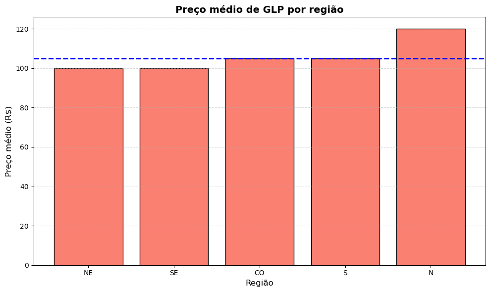

```python
# corrigir possíveis erros de formatação
df['Valor de Venda'] = df['Valor de Venda'].astype(str).str.replace(",", ".").str.replace('"', '').astype(float)

# Agrupar por estado e calcular preço médio
preco_regiao = df.groupby('Regiao - Sigla')['Valor de Venda'].median().reset_index(name='Preço Médio').round(2)
mediana_preco = df['Valor de Venda'].median()

# Limpar e converter os valores de venda
df['Valor de Venda'] = df['Valor de Venda'].astype(str).str.replace(",", ".").str.replace('"', '').astype(float)

# Agrupar por região e calcular a mediana dos preços
preco_regiao = df.groupby('Regiao - Sigla')['Valor de Venda'].median().round(2).sort_values()

# Criar gráfico de barras
plt.figure(figsize=(10, 6))
plt.bar(preco_regiao.index, preco_regiao.values, color='salmon', edgecolor='black')

# Estilizar o gráfico
plt.title('Preço médio de GLP por região', fontsize=14, fontweight='bold')
plt.xlabel('Região', fontsize=12)
plt.ylabel('Preço médio (R$)', fontsize=12)
plt.axhline(mediana_preco, color='blue', linestyle='--', linewidth=2, label=f'Mediana: R$ {mediana_preco:.2f}')
plt.grid(axis='y', linestyle='--', alpha=0.5)
plt.xticks(rotation=0)
plt.tight_layout()
plt.show()
```

### É possível observar que os preços na região norte estão muito acima da média.

# **4. Distribuição de bandeiras e revendas**

## 4.1 Distribuição estadual de bandeiras comerciais

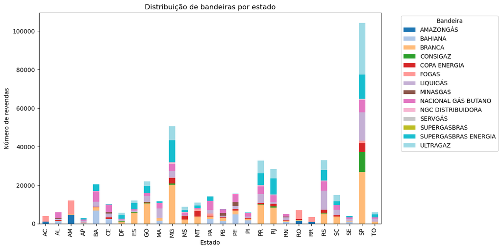

```python
# agrupar e contar o numero de bandeiras por estado
contagem = df.groupby(['Estado - Sigla', 'Bandeira']).size().unstack(fill_value=0)

# Configurar e exibir gráfico de barras empilhadas
contagem.plot(kind='bar', stacked=True, figsize=(12, 6), colormap='tab20')
plt.title('Distribuição de bandeiras por estado')
plt.xlabel('Estado')
plt.ylabel('Número de revendas')
plt.legend(title='Bandeira', bbox_to_anchor=(1.05, 1), loc='upper left')
plt.tight_layout()
plt.show()
```

### *Obs: A bandeira branca significa uma revendedora comercialmente idependente, que negocia diretamente com os forncedores sem contrato de exclusividade*

## 4.2 Concentração de bandeiras brancas por estado

```python
# Corrigir possíveis erros de formatação no valor de venda (opcional aqui, mas mantido por consistência)
df['Valor de Venda'] = df['Valor de Venda'].astype(str).str.replace(",", ".").str.replace('"', '').astype(float)

# Filtrar apenas bandeiras BRANCA
df_branca = df[df['Bandeira'].str.upper() == 'BRANCA']

# Contar número de revendas BRANCA por estado
contagem_branca = df_branca.groupby('Estado - Sigla').size().reset_index(name='Qtd Bandeira Branca')

# Carregar o arquivo GeoJSON com os dados dos estados
with open(r"C:\Users\renil\Downloads\brazil-states.geojson") as f:
    geojson = json.load(f)

# Criar e exibir o mapa coroplético
fig = px.choropleth(
    contagem_branca,
    geojson=geojson,
    locations='Estado - Sigla',
    color='Qtd Bandeira Branca',
    featureidkey='properties.sigla',
    scope='south america',
    color_continuous_scale='Blues'
)

fig.update_geos(fitbounds="locations", visible=False)
fig.update_layout(
    title_text='Concentração de Bandeiras Brancas por Estado',
    width=1000,
    height=800
)
fig.show()

fig.write_html(r"C:\Users\renil\Desktop\Analise_ExploratoriaGLP\Visualizacoes\mapa_glp2.html")
```

[interactive chart not shown]

## 4.3 Preço médio do GLP por bandeira

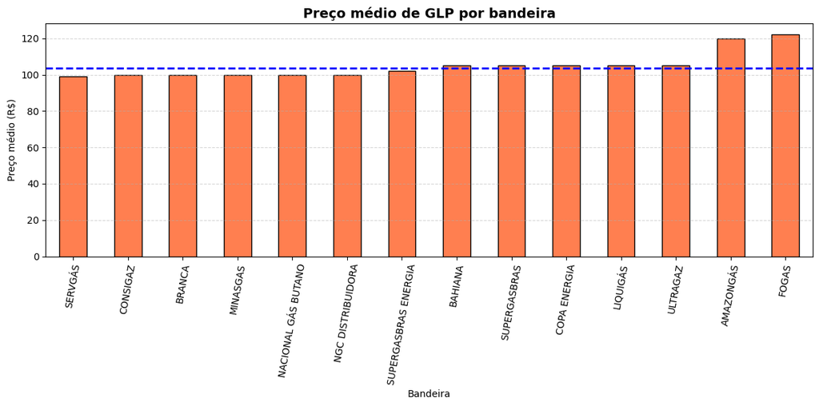

```python
# Agrupar e contar bandeiras por estado
preco_bandeira = df.groupby('Bandeira')['Valor de Venda'].median().round(2).sort_values()
mediana = preco_bandeira.median()

# Plotar gráfico de barras
plt.figure(figsize=(12, 6))
preco_bandeira.plot(kind='bar', color='coral', edgecolor='black')

# Estilizar
plt.title('Preço médio de GLP por bandeira', fontsize=14, fontweight='bold')
plt.xlabel('Bandeira')
plt.ylabel('Preço médio (R$)')
plt.axhline(mediana, color='blue', linestyle='--', linewidth=2, label=f'Mediana: R$ {mediana:.2f}')
plt.xticks(rotation=80)
plt.grid(axis='y', linestyle='--', alpha=0.5)
plt.tight_layout()
plt.show()
```

### Vale observar que a AMAZONGÁS e a FOGAS que monopolizam o mercado no Norte Brasileiro tem os preços mais acima da média (representada pela linha pontilhada azul)

## 4.2 Número de revendedoras por estado

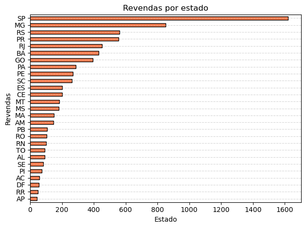

```python
# Agrupar e contar revendedoras por estado
revendas_por_estado = df.groupby('Estado - Sigla')['Revenda'].nunique().sort_values(ascending= False)

# Configurar e plotar gráfico
revendas_por_estado.plot(kind= "barh" , color= "Coral", edgecolor= 'black')
plt.title("Revendas por estado")
plt.xlabel("Estado")
plt.ylabel("Revendas")
plt.gca().invert_yaxis()
plt.grid(axis='y', linestyle='--', alpha=0.5)
plt.tight_layout()
plt.show()
```

## 4.3 Número de revendedoras por munícipio

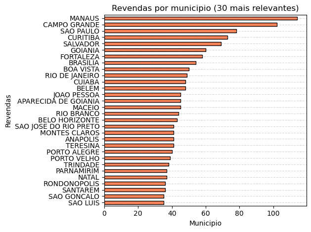

```python
# agrupar e contar numero de revendedoras por municipio
revendas_por_municipios = df.groupby('Municipio')['Revenda'].nunique().sort_values(ascending= False).head(30)

# configurar e exibir gráfico
revendas_por_municipios.plot(kind= "barh" , color= "Coral", edgecolor= 'black')
plt.title("Revendas por municipio (30 mais relevantes)")
plt.xlabel("Municipio")
plt.ylabel("Revendas")
plt.gca().invert_yaxis()
plt.grid(axis='y', linestyle='--', alpha=0.5)
plt.tight_layout()
plt.show()
```

# **5. Tendências temporais**

## 5.1 Evolução do preço do GLP ao longo dos anos (2023 - 2025)

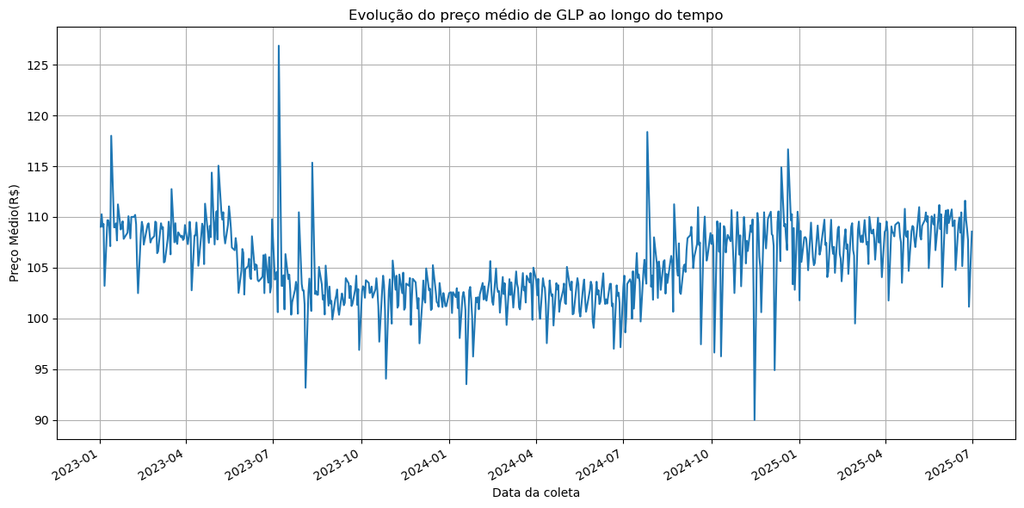

```python
# Corrigir erros de formatação e converter a coluna data para o formato datetime
df['Valor de Venda'] = df['Valor de Venda'].astype(str).str.replace(",", ".").str.replace('"', '').astype(float)
df['Data da Coleta'] = pd.to_datetime(df['Data da Coleta'], dayfirst=True)

# agrupar data de coleta e valor de venda
precos_tempo = df.groupby('Data da Coleta')['Valor de Venda'].mean()

# configurar e exibir gráfico
precos_tempo.plot(figsize=(12, 6))
plt.title('Evolução do preço médio de GLP ao longo do tempo')
plt.xlabel('Data da coleta')
plt.ylabel('Preço Médio(R$)')
plt.grid(True)
plt.tight_layout()
plt.show()
```

### É possível observar uma grande variação de preço ao longo do tempo, o que demonstra uma média de preço extremamente volátil.

## 5.2 Tendência mensal de preços do GLP

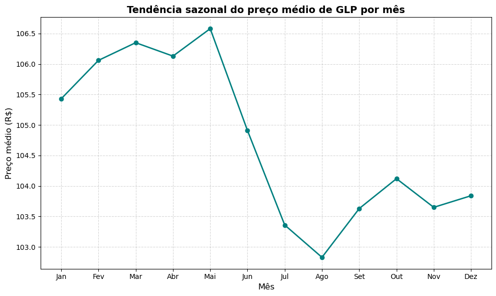

```python
# corrigir erros de formatação e formatar datas
df['Valor de Venda'] = df['Valor de Venda'].astype(str).str.replace(",", ".").str.replace('"', '').astype(float)
df['Data da Coleta'] = pd.to_datetime(df['Data da Coleta'], dayfirst=True)

# Extrair mês e ano
df['Ano'] = df['Data da Coleta'].dt.year
df['Mês'] = df['Data da Coleta'].dt.month

# Agrupar por mês e calcular média
sazonalidade = df.groupby('Mês')['Valor de Venda'].mean().round(2)

# Configurar e exibir gráfico
plt.figure(figsize=(10, 6))
plt.plot(sazonalidade.index, sazonalidade.values, marker='o', color='teal', linewidth=2)
plt.title('Tendência sazonal do preço médio de GLP por mês', fontsize=14, fontweight='bold')
plt.xlabel('Mês', fontsize=12)
plt.ylabel('Preço médio (R$)', fontsize=12)
plt.xticks(range(1, 13), ['Jan', 'Fev', 'Mar', 'Abr', 'Mai', 'Jun', 'Jul', 'Ago', 'Set', 'Out', 'Nov', 'Dez'])
plt.grid(True, linestyle='--', alpha=0.5)
plt.tight_layout()
plt.show()
```

### *Obs: Esse gráfico representa uma média dos mêses de todos os anos combinados, não de um ano específico*

# 6. Correlação entre variaveis

## 6.1 Matriz de correlação

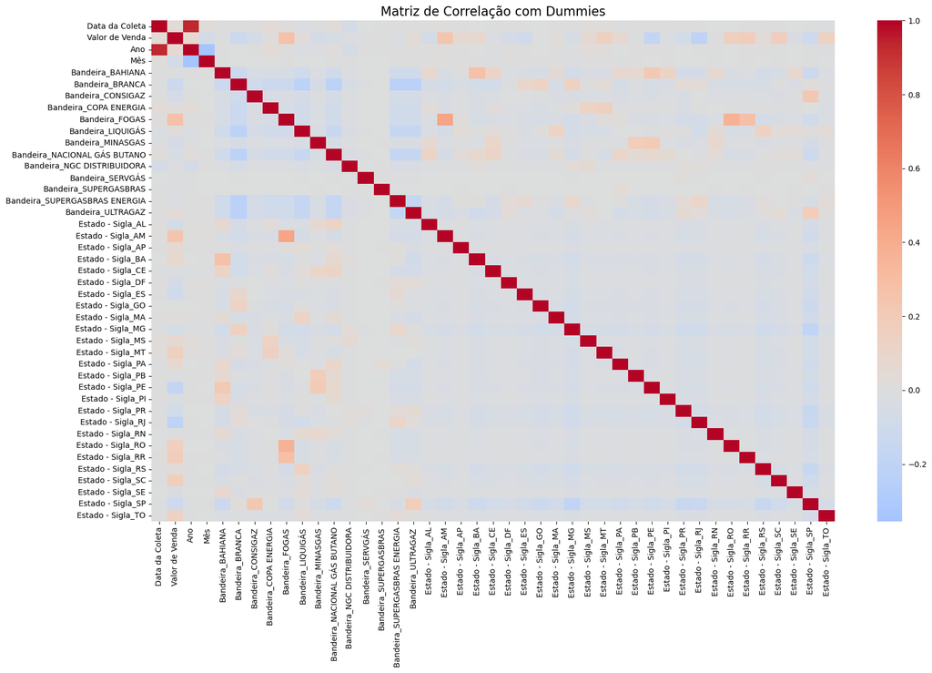

```python
# transformar variaveis não númericas em variaveis categóricas
df_dummies = pd.get_dummies(df, columns=['Bandeira', 'Estado - Sigla'], drop_first=True)
colunas_excluir = ['Regiao - Sigla', 'Municipio','Unidade de Medida' , 'Revenda']
df_dummies = df_dummies.drop(columns= colunas_excluir)

# calcular e exibir a matriz de correlação
correlacao = df_dummies.corr()
plt.figure(figsize=(18, 12))
sns.heatmap(correlacao, cmap='coolwarm', center=0)
plt.title('Matriz de Correlação com Dummies', fontsize=16)
plt.tight_layout()
plt.show()
```

# 7. Conclusão e resumo

## Através da análise explorátoria destes dados, foi possível observar, principalmente, que:

### O a média do preço do GLP ao longo do tempo é extremamente volátil, sempre variando e muito raramente se mantendo estável, o que provavelmente se deve a valores como inflação, preço do dólar. do petróleo e etc...

### No período de 2023 a 2025, o mês de Agosto se mostrou como o mês com o GLP mais barato e o mês de maio como o com maior preço médio.

### Através da matriz de correlação, é possível notar que algumas bandeiras estão posicionadas em faixas de preço diferentes, o que leva a possibilidade de que elas atuem em diferentes nichos (algo do tipo Premium x Popular)

# Autor: João Victor Bomfim Carvalho